# Reinforcement Learning: A Q-Learning Agent

Author

Michael Hahsler

This code is provided under [Creative Commons Attribution-ShareAlike 4.0 International (CC BY-SA 4.0) License.](https://creativecommons.org/licenses/by-sa/4.0/)

# 1 Introduction

AIMA chapter 22 is about *reinforcement learning* where the agent learns from reward signals. We will implement the key concepts using R for the AIMA 3x4 grid world example. A more detailed treatment of the algorithm and its properties can be found in [Reinforcement Learning: An Introduction (RL)](http://incompleteideas.net/book/the-book-2nd.html) by Sutton and Barto (2020) in Chapter 6: Temporal-Difference Learning.

The used environment is an MDP, but instead of trying to solve the MDP directly and estimating the value function estimates $U(s)$, we will try to learn a policy from interactions with the environment. The MDP’s transition model will only be used to simulate the response of the environment to actions by the agent.

The code in this notebook defines explicit functions matching the textbook definitions and is for demonstration purposes only. Efficient implementations for larger problems use fast vector multiplications instead.

# 2 The 4x3 Grid World Example

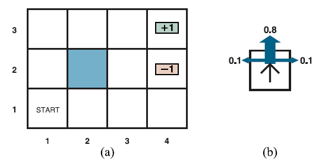

AIMA Figure 17.1: (a) A simple, stochastic $4 \times 3$ environment that presents the agent with a sequential decision problem. (b) Illustration of the transition model of the environment: the “intended” outcome occurs with probability 0.8, but with probability 0.2 the agent moves at right angles to the intended direction. A collision with a wall results in no movement. Transitions into the two terminal states have reward +1 and -1, respectively, and all other transitions have a reward of -0.04.

In the following, we implement states, actions, the reward function,and the transition model. We also show how to represent a policy and how to estimate the expected utility using simulation.

The MDP will be defined as the following global variables/functions:

- `S`: set of states.
- `A`: set of actions.
- `actions(s)`: returns the available actions for state $s$.
- `P(sp, s, a)`: a function returning the transition probability $P(s' | s, a)$.
- `R(s, a, s_prime)`: reward function for the transition from $s$ to $s`$ with action `a`.

Policies are represented as:

- Deterministic policies are a vector with the action for each state.
- Stochastic policies are a matrix with probabilities where each row is a state and the columns are the actions

Other useful functions:

- `sample_transition(s, a)`: returns a $s'$ sampled using the transition model.
- `simulate_utilities(pi, s0 = 1, N = 1000, max_t = 100)`: Estimates the utility of following policy $\pi$, starting $N$ episodes in state $s_0$. The maximal episode length is `max_t` to ensure that the function finishes also for policies that do not lead to a terminal state.

## 2.1 States

We define the atomic state space $S$ by labeling the states $1, 2, ...$. We convert coordinates `(rows, columns)` to the state label.

```r
# I use capitalized variables as global constants
COLS <- 4
ROWS <- 3

S = seq_len(ROWS * COLS)

LAYOUT <- matrix(S, nrow = ROWS , ncol = COLS)
LAYOUT
```

```
     [,1] [,2] [,3] [,4]
[1,]    1    4    7   10
[2,]    2    5    8   11
[3,]    3    6    9   12
```

Note that the rows are displayed upside-down compared to the text book, so we use a function to display them in reverse order.

```r
show_layout <- function(x) {
  x <- matrix(x, ncol = COLS, nrow = ROWS,
    dimnames = list(row = seq_len(ROWS), col = seq_len(COLS)))
  x[rev(seq_len(ROWS)), ]
  }

show_layout(LAYOUT)
```

```
   col
row 1 2 3  4
  3 3 6 9 12
  2 2 5 8 11
  1 1 4 7 10
```

Convert between coordinates and state labels.

```r
rc_to_s <- function(rc)
  LAYOUT[rbind(rc)]

s_to_rc <-
  function(s)
    drop(which(LAYOUT == s, arr.ind = TRUE, useNames = FALSE))


rc_to_s(c(3, 4))
```

```
[1] 12
```

```r
s_to_rc(12)
```

```
[1] 3 4
```

Start state

```r
start <- 1L
```

Define terminal states.

```r
is_terminal <- function(s) s %in% c(5, 11, 12)
```

## 2.2 Actions

The complete set of actions is $A = \{\mathrm{'Up', 'Right', 'Down', 'Left', 'None'}\}$. Not all actions are available in every state. Also, action `None` is added as the only possible action in an absorbing state.

```r
A = c('Up', 'Right', 'Down', 'Left', 'None')

actions <- function(s) {

  # absorbing states
  if(s == 11 || s == 12) return('None')

  # illegal state
  if(s == 5) return('None')

  c('Up', 'Right', 'Down', 'Left')
}

lapply(S, actions)
```

```
[[1]]
[1] "Up"    "Right" "Down"  "Left"

[[2]]
[1] "Up"    "Right" "Down"  "Left"

[[3]]
[1] "Up"    "Right" "Down"  "Left"

[[4]]
[1] "Up"    "Right" "Down"  "Left"

[[5]]
[1] "None"

[[6]]
[1] "Up"    "Right" "Down"  "Left"

[[7]]
[1] "Up"    "Right" "Down"  "Left"

[[8]]
[1] "Up"    "Right" "Down"  "Left"

[[9]]
[1] "Up"    "Right" "Down"  "Left"

[[10]]
[1] "Up"    "Right" "Down"  "Left"

[[11]]
[1] "None"

[[12]]
[1] "None"
```

## 2.3 Transition Model

$P(s' | s, a)$ is the probability of going from state $s$ to $s'$ by when taking action $a$. We will create a matrix $P_a(s' | s)$ for each action.

```r
calc_transition <- function(s, action) {
  action <- match.arg(action, choices = A)

  if(length(s) > 1) return(t(sapply(s, calc_transition, action = action)))

  # deal with absorbing and illegal state
  if(s == 11 || s == 12 || s == 5 || action == 'None') {
    P <- rep(0, length(S))
    P[s] <- 1
    return(P)
  }

  action_to_delta <- list(
    'Up' = c(+1, 0),
    'Down' = c(-1, 0),
    'Right' = c(0, +1),
    'Left' = c(0, -1)
    )
  delta <- action_to_delta[[action]]
  dr <- delta[1]
  dc <- delta[2]

  rc <- s_to_rc(s)
  r <- rc[1]
  c <- rc[2]

  if(dr != 0 && dc != 0)
    stop("You can only go up/down or right/left!")

  P <- matrix(0, nrow = ROWS, ncol = COLS)

  # UP/DOWN
  if(dr != 0) {
    new_r <- r + dr
    if(new_r > ROWS || new_r < 1) new_r <- r
    ## can't got to (2, 2)
    if(new_r == 2 && c  == 2) new_r <- r
    P[new_r, c] <- .8

    if(c < COLS & !(r == 2 & (c + 1) == 2))
      P[r, c + 1] <- .1 else P[r, c] <- P[r, c] + .1
    if(c > 1 & !(r == 2 & (c - 1) == 2))
      P[r, c - 1] <- .1 else P[r, c] <- P[r, c] + .1
  }

  # RIGHT/LEFT
  if(dc != 0) {
    new_c <- c + dc
    if(new_c > COLS || new_c < 1) new_c <- c
    ## can't got to (2, 2)
    if(r == 2 && new_c  == 2) new_c <- c
    P[r, new_c] <- .8

    if(r < ROWS & !((r + 1) == 2 & c  == 2))
      P[r + 1, c] <- .1 else P[r, c] <- P[r, c] + .1
    if(r > 1 & !((r - 1) == 2 & c == 2))
      P[r - 1, c] <- .1 else P[r, c] <- P[r, c] + .1
  }

  as.vector(P)
}
```

Try to go up from state 1 (this is (1,1), the bottom left corner). Note: we cannot go left so there is a .1 chance to stay in place.

```r
calc_transition(1, 'Up')
```

```
 [1] 0.1 0.8 0.0 0.1 0.0 0.0 0.0 0.0 0.0 0.0 0.0 0.0
```

```r
show_layout(calc_transition(1, 'Up'))
```

```
   col
row   1   2 3 4
  3 0.0 0.0 0 0
  2 0.8 0.0 0 0
  1 0.1 0.1 0 0
```

Try to go right from (2,1). Since right is blocked, there is a .8 probability of staying in place.

```r
show_layout(calc_transition(2, 'Right'))
```

```
   col
row   1 2 3 4
  3 0.1 0 0 0
  2 0.8 0 0 0
  1 0.1 0 0 0
```

Calculate transitions for each state to each other state. Each row represents a state $s$ and each column a state $s'$ so we get a complete definition for $P_a(s' | s)$. Note that the matrix is stochastic (all rows add up to 1).

Create a matrix for each action.

```r
P_matrices <- lapply(A, FUN = function(a) calc_transition(S, a))
names(P_matrices) <- A
str(P_matrices)
```

```
List of 5
 $ Up   : num [1:12, 1:12] 0.1 0 0 0.1 0 0 0 0 0 0 ...
 $ Right: num [1:12, 1:12] 0.1 0.1 0 0 0 0 0 0 0 0 ...
 $ Down : num [1:12, 1:12] 0.9 0.8 0 0.1 0 0 0 0 0 0 ...
 $ Left : num [1:12, 1:12] 0.9 0.1 0 0.8 0 0 0 0 0 0 ...
 $ None : num [1:12, 1:12] 1 0 0 0 0 0 0 0 0 0 ...
```

Create a function interface for $P(s' | s, a)$.

```r
P <- function(sp, s, a) P_matrices[[a]][s, sp]

P(2, 1, 'Up')
```

```
[1] 0.8
```

```r
P(5, 4, 'Up')
```

```
[1] 0
```

## 2.4 Reward

$R(s, a, s')$ define the reward for the transition from $s$ to $s'$ with action $a$.

For the textbook example we have:

- Any move costs utility (a reward of -0.04).
- Going to state 12 has a reward of +1
- Going to state 11 has a reward of -1.

Note that once you are in an absorbing state (11 or 12), then the problem is over and there is no more reward!

```r
R <- function(s, a, s_prime) {
  ## no more reward when we in 11 or 12.
  if(a == 'None' || s == 11 || s == 12) return(0)

  ## transition to the absorbing states.
  if(s_prime == 12) return(+1)
  if(s_prime == 11) return(-1)

  ## cost for each move
  return(-0.04)
}

R(1, 'Up', 2)
```

```
[1] -0.04
```

```r
R(9, 'Right', 12)
```

```
[1] 1
```

```r
R(12, 'None', 12)
```

```
[1] 0
```

## 2.5 Policy

The solution to an MDP is a policy $\pi$ which defines which action to take in each state. We represent deterministic policies as a vector of actions. I make up a policy that always goes up and then to the right once the agent hits the top.

```r
pi_manual <- rep('Up', times = length(S))
pi_manual[c(3, 6, 9)] <- 'Right'
pi_manual
```

```
 [1] "Up"    "Up"    "Right" "Up"    "Up"    "Right" "Up"    "Up"    "Right"
[10] "Up"    "Up"    "Up"
```

```r
show_layout(pi_manual)
```

```
   col
row 1       2       3       4
  3 "Right" "Right" "Right" "Up"
  2 "Up"    "Up"    "Up"    "Up"
  1 "Up"    "Up"    "Up"    "Up"
```

We can also create a random policy by randomly choosing from the available actions for each state.

```r
create_random_deterministic_policy <-
  function()
    structure(sapply(
      S,
      FUN = function(s)
        sample(actions(s), 1L)
    ), names = S)

set.seed(1234)
pi_random <- create_random_deterministic_policy()
pi_random
```

```
      1       2       3       4       5       6       7       8       9      10
 "Left"  "Left" "Right" "Right"  "None"  "Left"  "Down"    "Up"    "Up" "Right"
     11      12
 "None"  "None"
```

```r
show_layout(pi_random)
```

```
   col
row 1       2       3      4
  3 "Right" "Left"  "Up"   "None"
  2 "Left"  "None"  "Up"   "None"
  1 "Left"  "Right" "Down" "Right"
```

We can make a deterministic policy soft.

```r
make_policy_soft <-
  function(pi, epsilon = 0.1) {
    if(!is.vector(pi))
      stop("pi is not a deterministic policy!")

     p <-
      matrix(0,
             nrow = length(S),
             ncol = length(A),
             dimnames = list(S, A))

     for (s in S) {
      p[s, actions(s)] <- epsilon / length(actions(s))
      p[s, pi[s]] <- p[s, pi[s]] + (1 - epsilon)
     }

    p
  }

make_policy_soft(pi_random)
```

```
      Up Right  Down  Left None
1  0.025 0.025 0.025 0.925    0
2  0.025 0.025 0.025 0.925    0
3  0.025 0.925 0.025 0.025    0
4  0.025 0.925 0.025 0.025    0
5  0.000 0.000 0.000 0.000    1
6  0.025 0.025 0.025 0.925    0
7  0.025 0.025 0.925 0.025    0
8  0.925 0.025 0.025 0.025    0
9  0.925 0.025 0.025 0.025    0
10 0.025 0.925 0.025 0.025    0
11 0.000 0.000 0.000 0.000    1
12 0.000 0.000 0.000 0.000    1
```

Or we can create a completely random soft policy

```r
create_random_epsilon_soft_policy <-
  function(epsilon = 0.1) {

    # split total randomly into n numbers that add up to total
    random_split <- function(n, total) {
      if (n == 1)
        return(total)

      bordersR <- c(sort(runif(n - 1)), 1)
      bordersL <- c(0, bordersR[1:(n - 1)])
      (bordersR - bordersL) * total
    }

    p <-
      matrix(0,
             nrow = length(S),
             ncol = length(A),
             dimnames = list(S, A))
    for (s in S)
      p[s, actions(s)] <- epsilon / length(actions(s)) +
      random_split(n = length(actions(s)), 1 - epsilon)

    p
}

set.seed(1234)
pi_random_epsilon_soft <- create_random_epsilon_soft_policy()
pi_random_epsilon_soft
```

```
      Up Right  Down  Left None
1  0.127 0.471 0.037 0.365    0
2  0.586 0.040 0.224 0.150    0
3  0.034 0.226 0.415 0.326    0
4  0.488 0.053 0.159 0.301    0
5  0.000 0.000 0.000 0.000    1
6  0.279 0.034 0.593 0.094    0
7  0.265 0.042 0.521 0.171    0
8  0.193 0.066 0.101 0.640    0
9  0.061 0.132 0.154 0.653    0
10 0.222 0.301 0.281 0.195    0
11 0.000 0.000 0.000 0.000    1
12 0.000 0.000 0.000 0.000    1
```

## 2.6 Expected Utility

The expected utility can be calculated by

$U^\pi = E\left[\sum_{t=0}^\infty \gamma^t R(s_t, \pi(s_t), s_{t+1})\right]$

We need to define the discount factor.

```r
GAMMA <- 1
```

We can evaluate the utility of a policy using simulation. For the stochastic transition model, we need to be able to sample the state $s'$ the system transitions to when using action $a$ in state $s$.

```r
sample_transition <- function(s, a)
  sample(S, size = 1, prob = P_matrices[[a]][s,])

sample_transition(1, 'Up')
```

```
[1] 1
```

```r
table(replicate(n = 100, sample_transition(1, 'Up')))
```

```
 1  2  4
 9 84  7
```

We can now simulate the utility for one episode. Note that we use the cutoff `max_t` in case a policy does not end up in a terminal state before that.

```r
simulate_utility <- function(pi, s0 = 1, max_t = 100) {
  s <- s0
  U <- 0
  t <- 0

  while (TRUE) {
    ## get action from policy (matrix means it is a stochastic policy)
    if (!is.matrix(pi))
      a <- pi[s]
    else
      a <- sample(A, size = 1, prob = pi[s, ])

    ## sample a transition given the action from the policy
    s_prime <- sample_transition(s, a)

    ##
    U <- U + GAMMA ^ t * R(s, a, s_prime)

    s <- s_prime

    ## reached an absorbing state?
    if (s == 11 || s == 12 || s == 5)
      break

    t <- t + 1
    if (t >= max_t)
      break
  }

  U
}
```

Simulate the `N` episodes.

```r
simulate_utilities <- function(pi, s0 = 1, N = 1000, max_t = 100)
  replicate(N, simulate_utility(pi, s0, max_t))

utility_manual <- simulate_utilities(pi_manual)
```

The expected utility for starting from state $s_0 = 1$ is.

```r
mean(utility_manual)
```

```
[1] 0.7
```

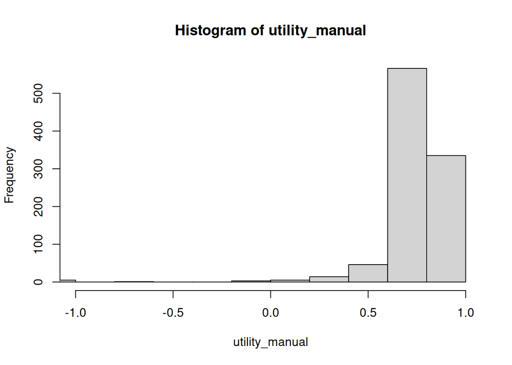

```r
hist(utility_manual, xlim = c(-1, 1))
```

Compare with the utility of the random policy.

```r
utility_random <- simulate_utilities(pi_random, max_t = 100)

table(utility_random)
```

```
utility_random
  -4
1000
```

The random policy performs really bad and most likely always stumbles around for `max_t` moves at a cost of .04 each. The manually created policy is obviously better.

We can use simulation to estimate the expected utility for starting from each state following the policy.

```r
U_manual <-
  sapply(
    S,
    FUN = function(s)
      mean(simulate_utilities(pi_manual, s0 = s))
  )
show_layout(U_manual)
```

```
   col
row    1     2    3     4
  3 0.86  0.90 0.95  0.00
  2 0.79 -0.04 0.72  0.00
  1 0.72  0.36 0.52 -0.87
```

```r
U_random <-
  sapply(
    S,
    FUN = function(s)
      mean(simulate_utilities(pi_random, s0 = s))
  )
show_layout(U_random)
```

```
   col
row  1    2    3    4
  3 -4 -4.0 -1.6  0.0
  2 -4  0.0 -1.5  0.0
  1 -4 -1.8 -1.8 -1.4
```

# 3 Q-Learning

Q-Learning is an off-policy TD control algorithm to estimate $Q \approx q_*.$ The pseudo code of a Q-Learning algorithm is given in AIMA Figure 22.8 as:

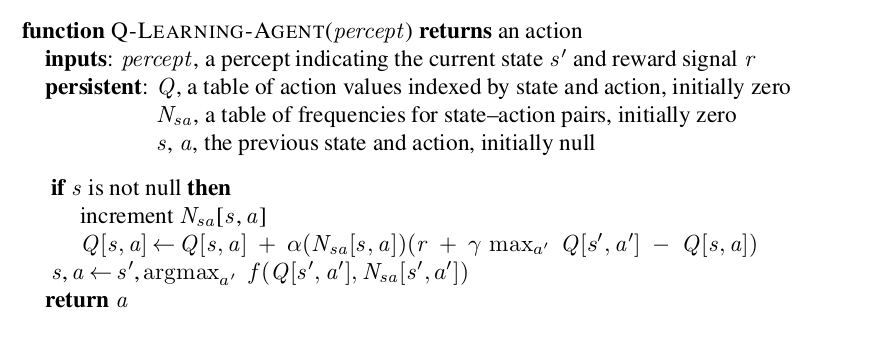

AIMA Figure 22.8: An exploratory Q-learning agent. It is an active learner that learns the value $Q(s, a)$ of each action in each situation. It uses the exploration function $f$.

The algorithm performs **off-policy learning** since it learns a different policy than the one used to perform actions.

- **Behavior policy:** is defined by the exploration function $f$. It needs to guarantee exploration. That is, every available action needs to have a chance to be tried. A popular policy is an $\epsilon$-greedy policy, but any $\epsilon$-soft policy that is increasing action probability with Q and decreases it with N can be used.
- **Target policy:** This is the learned policy. Q-learning learns a deterministic greedy policy represented by the $max_{a'} Q[s', a']$ in the update of Q.

## 3.1 Agent

The Q-learning agent parameters and helper functions.

```r
# helper: argmax breaking ties randomly.
argmax <- function (x)
{
    y <- seq_along(x)[x == max(x)]
    if (length(y) > 1L)
        sample(y, 1L)
    else y
}
```

We use a class to store persistent information: Agent state, $Q$ and $N$ tables. Reference classes use `<<-` to assign values to member variables (fields).

```r
QL_Agent <- setRefClass(
  "QL_Agent",
  fields = c("S", "A", "Q", "N", "s", "a", "gamma"),
  methods = list(
    initialize = function(S, A, gamma = 1) {
      S <<- S
      A <<- A
      gamma <<- gamma
      reset()
    },

    next_episode = function() {
      "Start a new episode."

      s <<- NULL
      a <<- 'None'
    },

    reset = function() {
      "Reset the agent's state and erase all persistent information."

      # set q-values to 0 except use NA for unavailable actions
      Q <<-
        matrix(NA_real_,
               nrow = length(S),
               ncol = length(A),
               dimnames = list(S, A))

      for (s in S) Q[s, actions(s)] <<- 0

      N <<-
        matrix(0L,
               nrow = length(S),
               ncol = length(A),
               dimnames = list(S, A))

      next_episode()
    }

  )
)
```

The agent function is called `run` with the precepts including the new state and the associated reward.

```r
QL_Agent$methods(
  # Learning rate:
  # Fixed learning rate
  #alpha = function(n, rate = 0.1) return(rate)

  # A decreasing learning rate converges faster. n is the number a
  # state was visited. The numbers depend on the problem.
  alpha = function(n) {
    return (10 / (9 + n))
  },

  # Exploration function (behavior policy): We use a simple
  # epsilon-greedy policy here.
  maxf = function(s_prime, a_best, epsilon = .8) {
    if (runif(1) < epsilon)
      action <- a_best
    else
      action <- sample(actions(s_prime), size = 1)

    return(action)
  },

  # Q-learning algorithm
  run = function(s_prime, r) {
    "Agent function. The pecepts are the current state and the last reward."

    # how often did the agent try this s/a combination
    N[s, a] <<- N[s, a] + 1L

    # Greedy target policy: find best available action for s' (breaking ties randomly).
    available_actions <- actions(s_prime)
    a_best <- available_actions[argmax(Q[s_prime,available_actions])]

    # No update for start of new episode
    if (!is.null(s)) {
      Q[s, a] <<-
        Q[s, a] + alpha(N[s, a]) * (r + gamma * Q[s_prime, a_best] - Q[s, a])
    }

    if (is_terminal(s_prime))
      a <<- 'None'
    else
      a <<- maxf(s_prime, a_best)

    s <<- s_prime

    return(a)
  }

)
```

Create an agent.

```r
agent <- QL_Agent$new(S, A)
agent
```

```
Reference class object of class "QL_Agent"
Field "S":
 [1]  1  2  3  4  5  6  7  8  9 10 11 12
Field "A":
[1] "Up"    "Right" "Down"  "Left"  "None"
Field "Q":
   Up Right Down Left None
1   0     0    0    0   NA
2   0     0    0    0   NA
3   0     0    0    0   NA
4   0     0    0    0   NA
5  NA    NA   NA   NA    0
6   0     0    0    0   NA
7   0     0    0    0   NA
8   0     0    0    0   NA
```

[output cut: 24 more lines]

## 3.2 Environment

This is an environment that can simulate $n$ episodes and returns the utility the agent received for each episode.

```r
simulate_environment <-
  function(n = 1000,
           agent,
           reset_agent = TRUE,
           verbose = FALSE) {

    reward_history <- numeric(n)
    state <- start

    if (reset_agent)
      agent$reset()
    agent$next_episode()

    i <- 1L # episode counter
    j <- 1L # step in episode counter
    reward <- 0
    reward_episode <- 0
    while (TRUE) {
      reward_episode <- reward_episode + GAMMA ^ j * reward

      # call agent function with percepts (current state and reward)
      action <- agent$run(state, reward)

      if (verbose) {
        if (j == 1L)
          cat("\n*** Episode", i , "***\n")
        cat("Step",
            j,
            paste0("(s = ", state, ", r = ",
                   reward, ") -> ", action),
            "\n")
      }

      j <- j + 1L

      if (is_terminal(state)) {
        reward_history[i] <- reward_episode
        if (verbose) {
          cat("Episode reward: ", reward_episode, "\n")

          cat("Q:\n")
          print(agent$Q)

          cat("U:\n")
          print(show_layout(apply(
            agent$Q, MARGIN = 1, max, na.rm = TRUE
          )))
        }

        j <- 1L

        # finished n episodes?
        i <- i + 1L
        if (i > n)
          break

        state <- start
        reward <- 0
        reward_episode <- 0

        agent$next_episode()
      }
      else
        if (action %in% actions(state)) {
          state_prime <- sample_transition(state, action)
          reward <- R(state, action, state_prime)
          state <- state_prime
        } else {
          stop("The agent chose an illegal action!")
          #reward <- -1e9
        }
    }
    reward_history
  }
```

## 3.3 Analyzing the First Few Episodes

Run a few episodes.

```r
simulate_environment(n = 10, agent, verbose = TRUE)
```

[output not shown]

[output cut: 323 more lines]

```
4  -0.112  0.54 -0.116 -0.15   NA
5      NA    NA     NA    NA    0
6  -0.084  0.72 -0.084 -0.12   NA
7   0.815 -0.04 -0.076 -0.08   NA
8   0.918 -1.00  0.000  0.72   NA
9   0.816  0.98 -0.040  0.00   NA
10 -1.000 -0.04 -0.040 -1.00   NA
11     NA    NA     NA    NA    0
12     NA    NA     NA    NA    0
U:
   col
row      1    2    3     4
  3 -0.098 0.72 0.98  0.00
  2 -0.135 0.00 0.92  0.00
  1  0.121 0.54 0.81 -0.04
```

```
 [1] -1.20 -1.16 -1.60 -0.64  0.64  0.40 -1.32  0.48  0.52  0.72
```

Note that the agent has initial no idea about the optimal policy and runs around randomly. After it randomly finds the goal, the rewards starts to spread one square every episode where the agent reaches the goal. Also, the agent starts to find the goal faster.

Calculate the value function $U$ from the learned Q-function as the largest Q value of any action in a state.

```r
U <- apply(agent$Q, MARGIN = 1, max, na.rm = TRUE)
show_layout(U)
```

```
   col
row      1    2    3     4
  3 -0.098 0.72 0.98  0.00
  2 -0.135 0.00 0.92  0.00
  1  0.121 0.54 0.81 -0.04
```

Note that not all states are reached the same amount of times and some estimates may be worse than others. Since Q-Learning uses a $\epsilon$-greedy behavior policy, the best actions are used most often leading to better estimates around the optimal policy.

Extract the learned policy from $Q$ as the action with the highest Q-value for each state.

```r
pi <- A[apply(agent$Q, MARGIN = 1, which.max)]
show_layout(pi)
```

```
   col
row 1       2       3       4
  3 "Down"  "Right" "Right" "None"
  2 "Up"    "None"  "Up"    "None"
  1 "Right" "Right" "Up"    "Right"
```

Even after simulating just 10 episodes, we get a reasonable policy that will lead the agent mostly to the goal state. We can estimate the expected utility of the policy using simulation.

```r
mean(simulate_utilities(pi, s0 = 1, N = 100))
```

```
[1] 0.3
```

## 3.4 Leaning a Good Policy

Simulating more episodes results in better estimates (also for the rarely visited states).

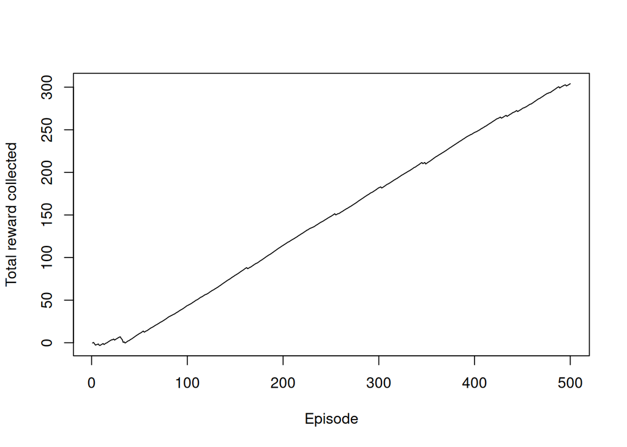

```r
reward_history <- simulate_environment(n = 10000, agent,
    verbose = FALSE, reset_agent = TRUE)

plot(cumsum(reward_history[1:500]), type = "l",
     ylab = "Total reward collected", xlab = "Episode")
```

The total reward approaches a straight line after just a few epochs, meaning that a reasonable policy was already found.

```r
show_layout(LAYOUT)
```

```
   col
row 1 2 3  4
  3 3 6 9 12
  2 2 5 8 11
  1 1 4 7 10
```

```r
agent$Q
```

```
      Up Right Down  Left None
1   0.75  0.67 0.70 0.715   NA
2   0.80  0.76 0.72 0.762   NA
3   0.82  0.85 0.78 0.810   NA
4   0.66  0.62 0.66 0.699   NA
5     NA    NA   NA    NA    0
6   0.87  0.91 0.87 0.829   NA
7   0.62  0.38 0.58 0.657   NA
8   0.66 -0.57 0.39 0.653   NA
9   0.92  0.96 0.71 0.860   NA
10 -0.40  0.18 0.24 0.078   NA
11    NA    NA   NA    NA    0
12    NA    NA   NA    NA    0
```

Learned state-value function.

```r
U <- apply(agent$Q, MARGIN = 1, max, na.rm = TRUE)
show_layout(U)
```

```
   col
row    1    2    3    4
  3 0.85 0.91 0.96 0.00
  2 0.80 0.00 0.66 0.00
  1 0.75 0.70 0.66 0.24
```

Extract the greedy policy.

```r
pi <- A[apply(agent$Q, MARGIN = 1, which.max)]
show_layout(pi)
```

```
   col
row 1       2       3       4
  3 "Right" "Right" "Right" "None"
  2 "Up"    "None"  "Up"    "None"
  1 "Up"    "Left"  "Left"  "Down"
```

We can estimate the expected utility of the policy using simulation.

```r
mean(simulate_utilities(pi, s0 = 1, N = 100))
```

```
[1] 0.7
```